# **Priming Mindfulness Project 2**

Comparison & analysis report

Rémi Thériault

2023-05-04

# Introduction

This report describes the results of a preregistered study available at: https://osf.io/582wx.

Note also that this data has been cleaned beforehand. Three datasets were merged (joined) through an inner join—2 Qualtrics surveys and 1 Inquisit task—so as to keep only participants who at least participated at each step of the study. Missing data will be imputed later on. Duplicates were addressed with the `rempsyc::best_duplicate` function, which keeps the duplicate with the least amount of missing values, and in case of ties, takes the first occurrence.

# Packages & Data

## Packages

```r
library(rempsyc)
library(dplyr)
library(interactions)
library(performance)
library(see)
library(report)
library(datawizard)
library(bestNormalize)
library(psych)
library(visdat)
library(missForest)
library(doParallel)
library(naniar)

summary(report(sessionInfo()))
```

## Data

```r
# Read data
data <- read.table("https://osf.io/ecqng/?action=download", sep = "\t", header = TRUE)

# Dummy-code group variable
data <- data %>%
  mutate(condition_dum = ifelse(condition == "Mindfulness", 1, 0),
         condition = as.factor(condition))

cat(report_participants(data, threshold = 1))
```

377 participants (Mean age = 42.9, SD = 12.7, range: [21, 81]; Gender: 58.4% women, 40.1% men, 1.59% non-binary; Country: 100.00% United States of America; Race: 75.60% White, 10.61% Black or African American, 7.16% Asian, 4.24% Mixed, 2.39% other)

```r
# Allocation ratio
report(data$condition)
```

x: 2 levels, namely Control (n = 189, 50.13%) and Mindfulness (n = 188, 49.87%)

## Preparation

At this stage, we define a list of our relevant variables.

```r
# Make list of DVs
col.list <- c("blastintensity.duration", "KIMS", "BSCS", "BAQ")
```

# Data cleaning

In this section, we are preparing the data for analysis: (a) taking care of preliminary exclusions, (b) checking for and exploring missing values, (d) imputing missing data with `missForest`, (e) computing scale means, and (f) extracting reliability indices for our scales.

## Preliminary exclusions

We know that we only want to keep participants who had at least an 80% success rate in the critical experimental manipulation task. Let’s see how many participants have less than an 80% success rate. Those with missing values for variable `manipsuccessleft` will also be excluded since they have not completed the critical experimental manipulation in this study.

```r
data %>%
    summarize(success.80 = sum(manipsuccessleft < .80,
                               na.rm = TRUE),
              is.na = sum(is.na(manipsuccessleft)))
```

| success.80 | is.na |
| --- | --- |
| 10 | 0 |

There’s 10 people with success smaller than 80%, let’s exclude them.

```r
data <- data %>%
    filter(manipsuccessleft >= .80)

cat(report_participants(data, threshold = 1))
```

367 participants (Mean age = 43.1, SD = 12.8, range: [21, 81]; Gender: 58.9% women, 39.5% men, 1.63% non-binary; Country: 100.00% United States of America; Race: 76.57% White, 9.54% Black or African American, 7.08% Asian, 4.36% Mixed, 2.45% other)

Let’s also exclude those who failed 2 or more attention checks (i.e., keep with those with a score of two or more).

```r
data <- data %>%
    mutate(att_check = rowSums(
      select(., att_check1, att_check2, att_check3)))

data %>%
  count(att_check)
```

| att_check | n |
| --- | --- |
| 1 | 5 |
| 2 | 17 |
| 3 | 345 |

There’s 5 more exclusions here.

```r
data <- data %>%
  filter(att_check >= 2)

cat(report_participants(data, threshold = 1))
```

362 participants (Mean age = 43.3, SD = 12.7, range: [21, 81]; Gender: 59.1% women, 39.2% men, 1.66% non-binary; Country: 100.00% United States of America; Race: 76.52% White, 9.67% Black or African American, 7.18% Asian, 4.42% Mixed, 2.21% other)

```r
report(data$condition)
```

x: 2 levels, namely Control (n = 184, 50.83%) and Mindfulness (n = 178, 49.17%)

## Explore missing data

### Missing items

```r
# Check for nice_na
nice_na(data, scales = c("BSCS", "BAQ", "KIMS"))
```

| var | items | na | cells | na_percent | na_max | na_max_percent | all_na |
| --- | --- | --- | --- | --- | --- | --- | --- |
| BSCS_1:BSCS_7 | 7 | 0 | 2534 | 0.00 | 0 | 0.00 | 0 |
| BAQ_1:BAQ_12 | 12 | 0 | 4344 | 0.00 | 0 | 0.00 | 0 |
| KIMS_1:KIMS_39 | 39 | 2 | 14118 | 0.01 | 2 | 5.13 | 0 |
| Total | 93 | 18 | 33666 | 0.05 | 2 | 2.15 | 0 |

No missing data for our scales of interest, yeah! Except 2 items for KIMS.

### Patterns of missing data

Let’s check for patterns of missing data.

```r
# Smaller subset of data for easier inspection
data %>%
  select(country.ip:att_check2_raw,
         condition:condition_dum) %>%
  vis_miss
```

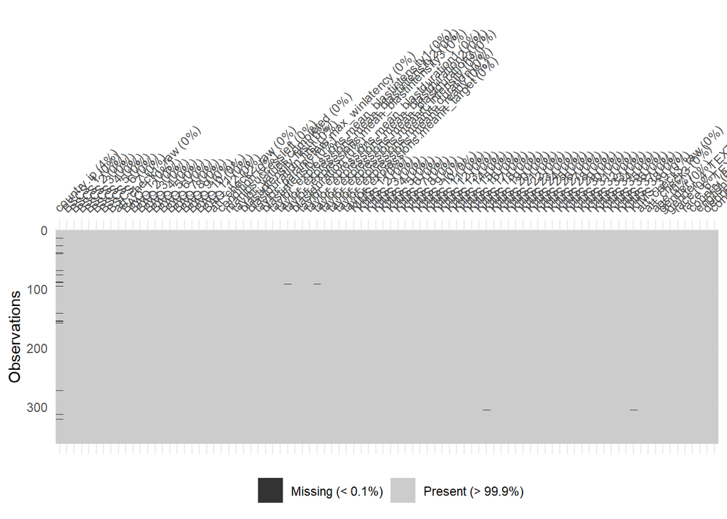

### Little’s MCAR test

```r
# Let's use Little's MCAR test to confirm
# We have to proceed by "scale" because the function can only
# support 30 variables max at a time
data %>%
  select(KIMS_1:KIMS_20) %>%
  mcar_test
```

| statistic | df | p.value | missing.patterns |
| --- | --- | --- | --- |
| 34.74096 | 19 | 0.0150041 | 2 |

```r
data %>%
  select(KIMS_21:KIMS_39) %>%
  mcar_test
```

| statistic | df | p.value | missing.patterns |
| --- | --- | --- | --- |
| 17.94261 | 18 | 0.4594394 | 2 |

## Impute missing data

### …

Here, we impute missing data with the `missForest` package, as it is one of the best imputation methods.

### Imputation

```r
# Need character variables as factors
# "Error: Can not handle categorical predictors with more than 53 categories."
# So we have to temporarily remove some variables also...
new.data <- data %>%
  select(-c(att_check1, att_check2, att_check3)) %>%
  mutate(across(where(is.character), as.factor))

# Parallel processing
registerDoParallel(cores = 4)

# Variables
set.seed(100)
data.imp <- missForest(new.data, verbose = TRUE, parallelize = "variables")
```

```
##   parallelizing over the variables of the input data matrix 'xmis'
##   missForest iteration 1 in progress...done!
##     estimated error(s): 0.02945581 0
##     difference(s): 0.0000006143571 0
##     time: 1.09 seconds
##
##   missForest iteration 2 in progress...done!
##     estimated error(s): 0.02922383 0
##     difference(s): 0.0000001056202 0
##     time: 0.71 seconds
##
##   missForest iteration 3 in progress...done!
##     estimated error(s): 0.0294241 0
##     difference(s): 0.00000002256135 0
##     time: 0.7 seconds
##
##   missForest iteration 4 in progress...done!
##     estimated error(s): 0.02951201 0
##     difference(s): 0.000000004421598 0
##     time: 0.67 seconds
##
##   missForest iteration 5 in progress...done!
##     estimated error(s): 0.0300375 0
##     difference(s): 0.00000006240112 0
##     time: 0.74 seconds
```

```r
# Total time is 2 sec (4*0.5) - 4 cores

# Extract imputed dataset
new.data <- data.imp$ximp
```

There are some variables we don’t actually want to impute, like country. We want to keep those NAs in that case. Let’s add them back. We also want to add ID back.

```r
# Add back the NAs in country, attention checks, etc.
data <- new.data %>%
  mutate(country.ip = data$country.ip,
         gender = data$gender,
         att_check1 = data$att_check1,
         att_check2 = data$att_check2,
         att_check3 = data$att_check3)
```

### Details

Why impute the data? van Ginkel explains,

> Regardless of the missingness mechanism, multiple imputation is always to be preferred over listwise deletion. Under MCAR it is preferred because it results in more statistical power, under MAR it is preferred because besides more power it will give unbiased results whereas listwise deletion may not, and under NMAR it is also the preferred method because it will give less biased results than listwise deletion.

van Ginkel, J. R., Linting, M., Rippe, R. C. A., & van der Voort, A. (2020). Rebutting existing misconceptions about multiple imputation as a method for handling missing data. *Journal of Personality Assessment*, *102*(3), 297-308. https://doi.org/10.1080/00223891.2018.1530680

Why `missForest`? It outperforms other imputation methods, including the popular MICE (multiple imputation by chained equations). You also don’t end up with several datasets, which makes it easier for following analyses. Finally, it can be applied to mixed data types (missings in numeric & categorical variables).

Waljee, A. K., Mukherjee, A., Singal, A. G., Zhang, Y., Warren, J., Balis, U., … & Higgins, P. D. (2013). Comparison of imputation methods for missing laboratory data in medicine. *BMJ open*, *3*(8), e002847. https://doi.org/10.1093/bioinformatics/btr597

Stekhoven, D. J., & Bühlmann, P. (2012). MissForest—non-parametric missing value imputation for mixed-type data. *Bioinformatics*, *28*(1), 112-118. https://doi.org/10.1093/bioinformatics/btr597

## Scale Means

### …

Now that we have imputed the missing data, we are ready to calculate our scale means.

### Self-control

```r
# Reverse code items 2, 4, 6, 7
data <- data %>%
  mutate(across(starts_with("BSCS"), .names = "{col}r"))

data <- data %>%
  mutate(across(c(BSCS_2, BSCS_4, BSCS_6, BSCS_7), ~nice_reverse(.x, 5), .names = "{col}r"))

# Get mean BSCS
data <- data %>%
  mutate(BSCS = rowMeans(select(., BSCS_1r:BSCS_7r)))
```

### Trait aggression

```r
# Reverse code item 7
data <- data %>%
  mutate(across(starts_with("BAQ"), .names = "{col}r"))

data <- data %>%
  mutate(across(BAQ_7, ~nice_reverse(.x, 7), .names = "{col}r"))

# Get sum of BAQ
data <- data %>%
  mutate(BAQ = rowMeans(select(., BAQ_1r:BAQ_12r)))
```

### Trait Mindfulness

```r
# Reverse code items 3-4, 8, 11-12, 14, 16, 18, 20, 22, 23-24, 27-28, 31-32, 35-36
data <- data %>%
  mutate(across(starts_with("KIMS"), .names = "{col}r"))

data <- data %>%
  mutate(across(all_of(paste0("KIMS_", c(3:4, 8, 11:12, 14, 16, 18, 20,
                                         22:24, 27:28, 31:32, 35:36))),
                ~nice_reverse(.x, 5), .names = "{col}r"))

# Get sum of KIMS
data <- data %>%
  mutate(KIMS = rowMeans(select(., KIMS_1r:KIMS_39r)))
```

### Intensity * Duration

```r
# Create new variable blastintensity.duration
data <- data %>%
  mutate(blastintensity.duration = blastintensity * blastduration)
```

## Reliability

### …

Now that we have reversed our items, we can get the alphas for our different scales.

### Self-control

```r
data %>%
  select(BSCS_1r:BSCS_7r) %>%
  omega(nfactors = 1)
```

```
## Omega_h for 1 factor is not meaningful, just omega_t
```

```
## Omega
## Call: omegah(m = m, nfactors = nfactors, fm = fm, key = key, flip = flip,
##     digits = digits, title = title, sl = sl, labels = labels,
##     plot = plot, n.obs = n.obs, rotate = rotate, Phi = Phi, option = option,
##     covar = covar)
## Alpha:                 0.84
## G.6:                   0.84
## Omega Hierarchical:    0.84
## Omega H asymptotic:    1
## Omega Total            0.84
##
## Schmid Leiman Factor loadings greater than  0.2
##            g  F1*   h2   u2 p2
## BSCS_1r 0.71      0.50 0.50  1
## BSCS_2r 0.71      0.51 0.49  1
## BSCS_3r 0.58      0.34 0.66  1
## BSCS_4r 0.70      0.49 0.51  1
## BSCS_5r 0.55      0.30 0.70  1
## BSCS_6r 0.70      0.49 0.51  1
## BSCS_7r 0.59      0.35 0.65  1
##
## With Sums of squares  of:
##   g F1*
##   3   0
##
## general/max  53819065016928536   max/min =   1
## mean percent general =  1    with sd =  0 and cv of  0
## Explained Common Variance of the general factor =  1
##
## The degrees of freedom are 14  and the fit is  0.38
## The number of observations was  362  with Chi Square =  137.2  with prob <  0.00000000000000000000026
## The root mean square of the residuals is  0.08
## The df corrected root mean square of the residuals is  0.1
## RMSEA index =  0.156  and the 10 % confidence intervals are  0.133 0.18
## BIC =  54.72
##
## Compare this with the adequacy of just a general factor and no group factors
## The degrees of freedom for just the general factor are 14  and the fit is  0.38
## The number of observations was  362  with Chi Square =  137.2  with prob <  0.00000000000000000000026
## The root mean square of the residuals is  0.08
## The df corrected root mean square of the residuals is  0.1
##
## RMSEA index =  0.156  and the 10 % confidence intervals are  0.133 0.18
## BIC =  54.72
##
## Measures of factor score adequacy
##                                                  g F1*
## Correlation of scores with factors            0.92   0
## Multiple R square of scores with factors      0.85   0
## Minimum correlation of factor score estimates 0.69  -1
##
##  Total, General and Subset omega for each subset
##                                                  g  F1*
## Omega total for total scores and subscales    0.84 0.84
## Omega general for total scores and subscales  0.84 0.84
## Omega group for total scores and subscales    0.00 0.00
```

### Trait aggression

```r
data %>%
  select(BAQ_1r:BAQ_12r) %>%
  omega(nfactors = 1)
```

```
## Omega_h for 1 factor is not meaningful, just omega_t
```

```
## Omega
## Call: omegah(m = m, nfactors = nfactors, fm = fm, key = key, flip = flip,
##     digits = digits, title = title, sl = sl, labels = labels,
##     plot = plot, n.obs = n.obs, rotate = rotate, Phi = Phi, option = option,
##     covar = covar)
## Alpha:                 0.83
## G.6:                   0.87
## Omega Hierarchical:    0.84
## Omega H asymptotic:    1
## Omega Total            0.84
##
## Schmid Leiman Factor loadings greater than  0.2
##            g  F1*   h2   u2 p2
## BAQ_1r  0.67      0.45 0.55  1
## BAQ_2r  0.61      0.37 0.63  1
## BAQ_3r  0.69      0.48 0.52  1
## BAQ_4r            0.02 0.98  1
## BAQ_5r  0.47      0.22 0.78  1
## BAQ_6r  0.60      0.36 0.64  1
## BAQ_7r  0.44      0.19 0.81  1
## BAQ_8r  0.68      0.46 0.54  1
## BAQ_9r  0.73      0.53 0.47  1
## BAQ_10r 0.51      0.26 0.74  1
## BAQ_11r 0.52      0.27 0.73  1
## BAQ_12r 0.52      0.27 0.73  1
##
## With Sums of squares  of:
##   g F1*
## 3.9 0.0
##
## general/max  39866478821986264   max/min =   1
## mean percent general =  1    with sd =  0 and cv of  0
## Explained Common Variance of the general factor =  1
##
## The degrees of freedom are 54  and the fit is  1.81
## The number of observations was  362  with Chi Square =  645.14  with prob <  0.0000000000000000000000000000000000000000000000000000000000000000000000000000000000000000000000000000037
## The root mean square of the residuals is  0.13
## The df corrected root mean square of the residuals is  0.14
## RMSEA index =  0.174  and the 10 % confidence intervals are  0.162 0.186
## BIC =  326.99
##
## Compare this with the adequacy of just a general factor and no group factors
## The degrees of freedom for just the general factor are 54  and the fit is  1.81
## The number of observations was  362  with Chi Square =  645.14  with prob <  0.0000000000000000000000000000000000000000000000000000000000000000000000000000000000000000000000000000037
## The root mean square of the residuals is  0.13
## The df corrected root mean square of the residuals is  0.14
##
## RMSEA index =  0.174  and the 10 % confidence intervals are  0.162 0.186
## BIC =  326.99
##
## Measures of factor score adequacy
##                                                  g F1*
## Correlation of scores with factors            0.93   0
## Multiple R square of scores with factors      0.87   0
## Minimum correlation of factor score estimates 0.73  -1
##
##  Total, General and Subset omega for each subset
##                                                  g  F1*
## Omega total for total scores and subscales    0.84 0.84
## Omega general for total scores and subscales  0.84 0.84
## Omega group for total scores and subscales    0.00 0.00
```

### Trait Mindfulness

```r
data %>%
  select(KIMS_1r:KIMS_39r) %>%
  omega(nfactors = 1)
```

```
## Omega_h for 1 factor is not meaningful, just omega_t
```

```
## Warning in schmid(m, nfactors, fm, digits, rotate = rotate, n.obs = n.obs, :
## Omega_h and Omega_asymptotic are not meaningful with one factor
```

```
## Omega
## Call: omegah(m = m, nfactors = nfactors, fm = fm, key = key, flip = flip,
##     digits = digits, title = title, sl = sl, labels = labels,
##     plot = plot, n.obs = n.obs, rotate = rotate, Phi = Phi, option = option,
##     covar = covar)
## Alpha:                 0.9
## G.6:                   0.94
## Omega Hierarchical:    0.89
## Omega H asymptotic:    0.99
## Omega Total            0.9
##
## Schmid Leiman Factor loadings greater than  0.2
##             g  F1*   h2   u2 p2
## KIMS_1r  0.42      0.18 0.82  1
## KIMS_2r  0.75      0.56 0.44  1
## KIMS_3r  0.52      0.27 0.73  1
## KIMS_4r  0.45      0.20 0.80  1
## KIMS_5r  0.41      0.17 0.83  1
## KIMS_6r  0.75      0.56 0.44  1
## KIMS_7r  0.33      0.11 0.89  1
## KIMS_8r-           0.00 1.00  1
## KIMS_9r  0.36      0.13 0.87  1
## KIMS_10r 0.72      0.52 0.48  1
## KIMS_11r 0.34      0.12 0.88  1
## KIMS_12r 0.43      0.19 0.81  1
## KIMS_13r 0.49      0.24 0.76  1
## KIMS_14r 0.69      0.47 0.53  1
## KIMS_15r 0.48      0.23 0.77  1
## KIMS_16r 0.40      0.16 0.84  1
## KIMS_17r 0.38      0.15 0.85  1
## KIMS_18r 0.69      0.47 0.53  1
## KIMS_19r 0.22      0.05 0.95  1
## KIMS_20r           0.01 0.99  1
## KIMS_21r 0.51      0.26 0.74  1
## KIMS_22r 0.54      0.29 0.71  1
## KIMS_23r 0.48      0.23 0.77  1
## KIMS_24r 0.20      0.04 0.96  1
## KIMS_25r 0.39      0.15 0.85  1
## KIMS_26r 0.57      0.32 0.68  1
## KIMS_27r 0.25      0.06 0.94  1
```

[output cut: 33 more lines]

```
##
## RMSEA index =  0.12  and the 10 % confidence intervals are  0.117 0.124
## BIC =  250.17
##
## Measures of factor score adequacy
##                                                  g F1*
## Correlation of scores with factors            0.96   0
## Multiple R square of scores with factors      0.92   0
## Minimum correlation of factor score estimates 0.85  -1
##
##  Total, General and Subset omega for each subset
##                                                  g  F1*
## Omega total for total scores and subscales    0.90 0.89
## Omega general for total scores and subscales  0.89 0.89
## Omega group for total scores and subscales    0.00 0.00
```

```r
#labels.part2$KIMS_8
```

8. “I tend to evaluate whether my perceptions are right or wrong.”

Which corresponds to items 17 and 19 as described in the original paper (Baer, Smith, & Allen in 2004). They also make sense to not reverse-score, theoretically speaking; they seem to relate to mindfulness, not its absence. So it is kind of strange that `psych::alpha` is suggesting to reverse-score these items. Perhaps the scale is not meant to be used as a single factor since it contains four factor subscales.

# t-tests

In this section, we will: (a) test assumptions of normality, (b) transform variables violating assumptions, (c) test assumptions of homoscedasticity, (d) identify and winsorize outliers, and (e) conduct the t-tests.

## Normality

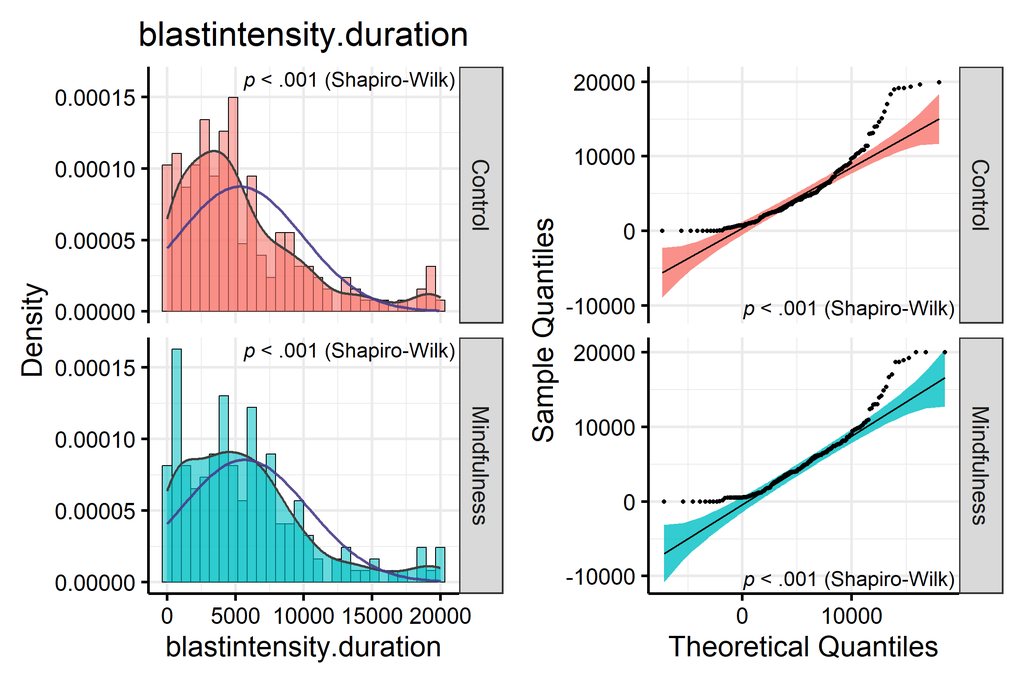

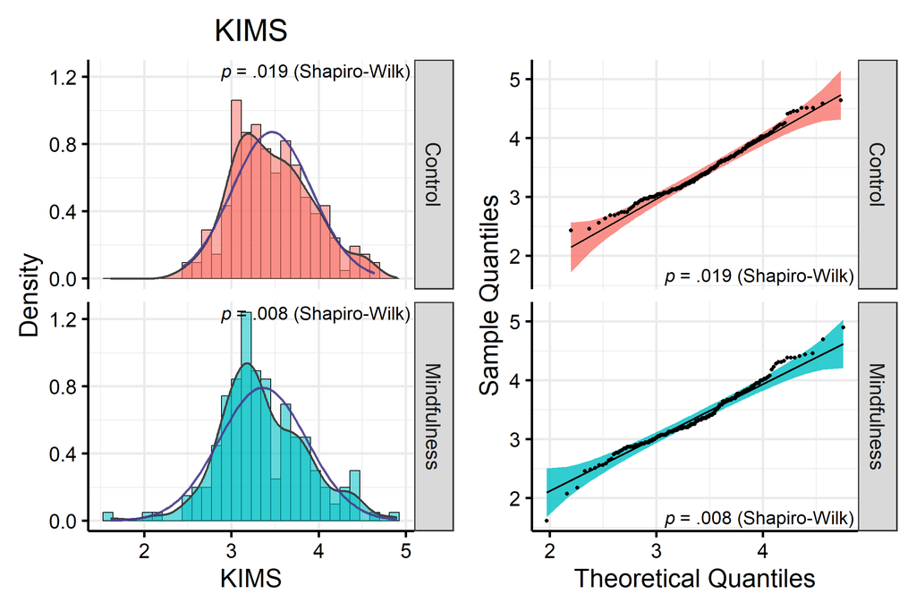

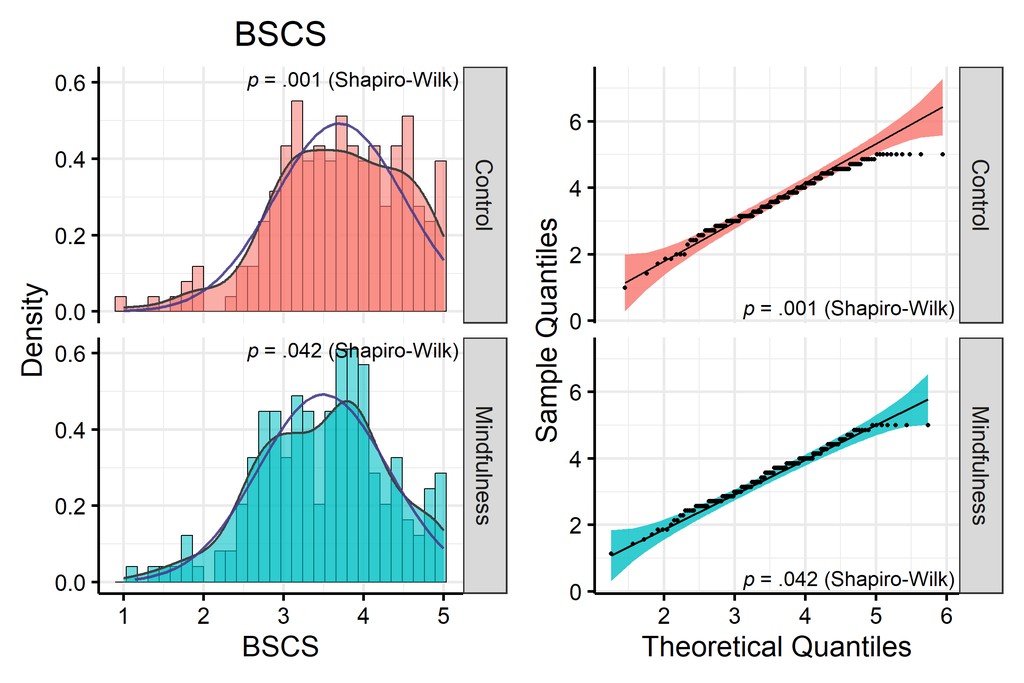

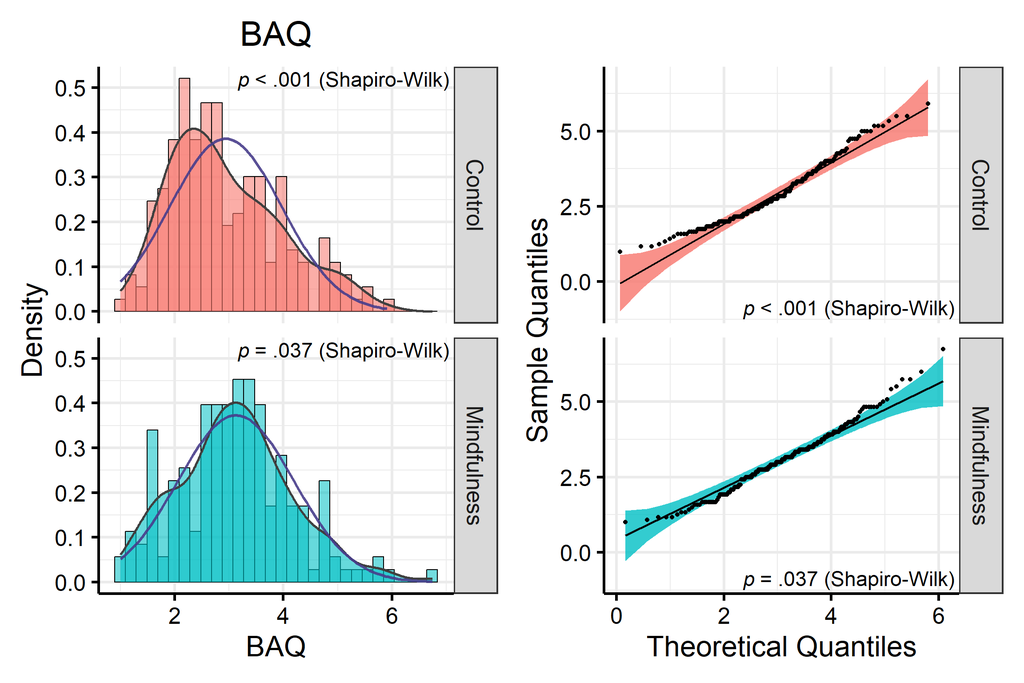

```r
lapply(col.list, function(x)
  nice_normality(data,
                 variable = x,
                 title = x,
                 group = "condition",
                 shapiro = TRUE,
                 histogram = TRUE))
```

## Transformation

```r
predict_bestNormalize <- function(var) {
  x <- bestNormalize(var, standardize = FALSE, allow_orderNorm = FALSE)
  print(cur_column())
  print(x$chosen_transform)
  cat("\n")
  predict(x)
}

set.seed(100)
data <- data %>%
  mutate(across(all_of(col.list),
                predict_bestNormalize,
                .names = "{.col}.t"))
```

[output not shown]

```r
col.list <- paste0(col.list, ".t")
```

> *Note.* The I(x) transformations above are actually not transformations, but a shorthand function for passing the data “as is”. Suggesting the package estimated the various attempted transformations did not improve normality in those cases, so no transformation is used. This only appears when standardize is set to FALSE. When set to TRUE, for those variables, it is actually center_scale(x), suggesting that the data are only CENTERED because they need no transformation (no need to be scaled), only to be centered.

Let’s check if normality was corrected.

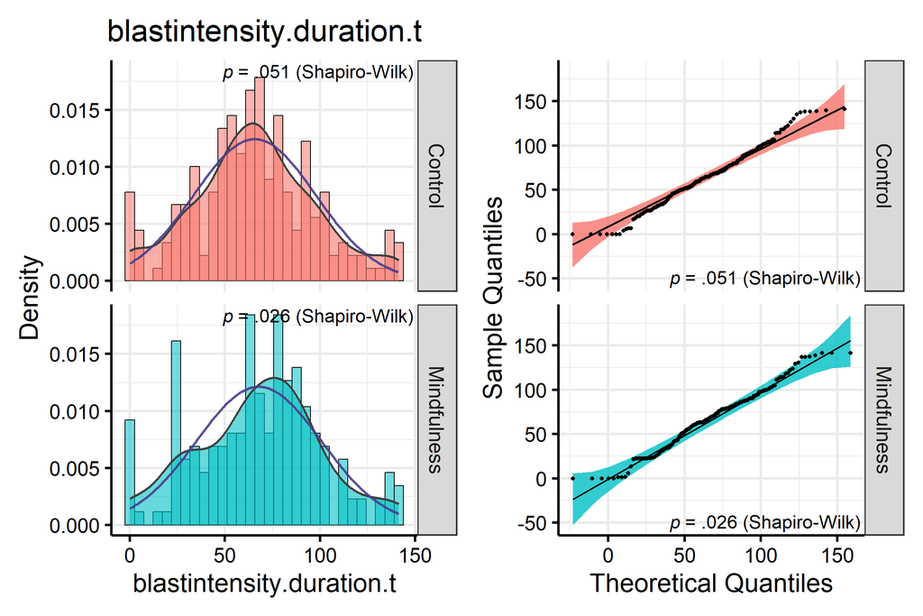

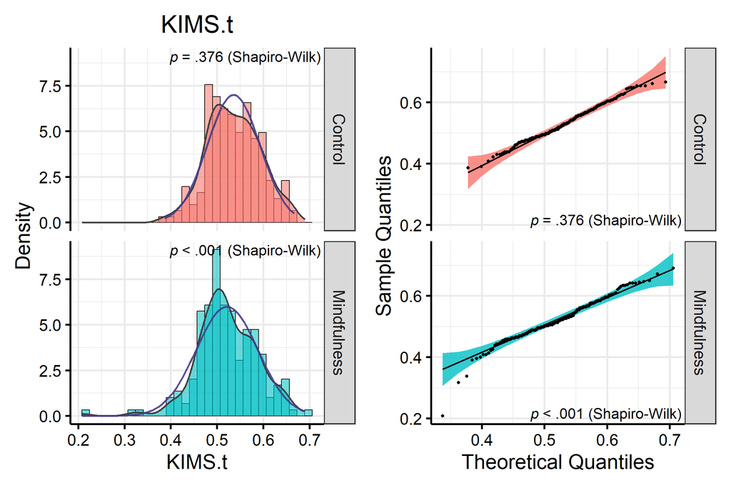

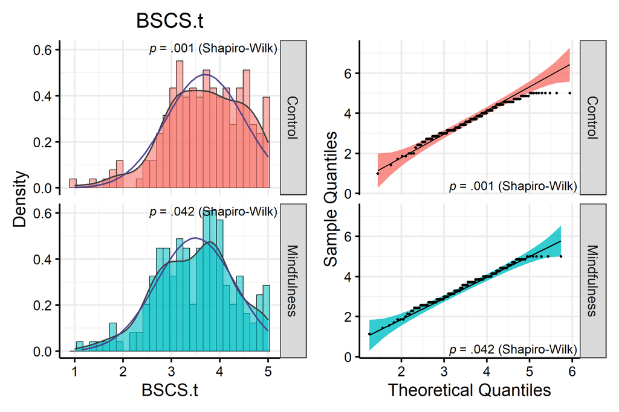

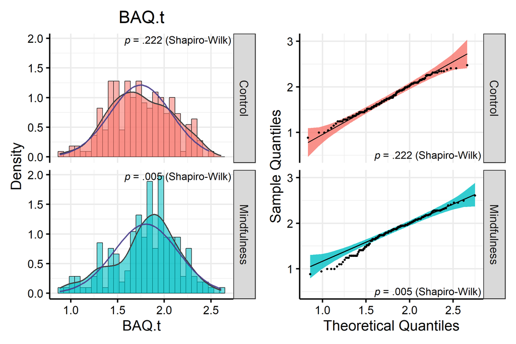

```r
# Group normality
lapply(col.list, function(x)
  nice_normality(data,
                 x,
                 "condition",
                 shapiro = TRUE,
                 title = x,
                 histogram = TRUE))
```

Looks rather reasonable now, though not perfect (fortunately t-tests are quite robust against violations of normality).

We can now resume with the next step: checking variance.

## Homoscedasticity

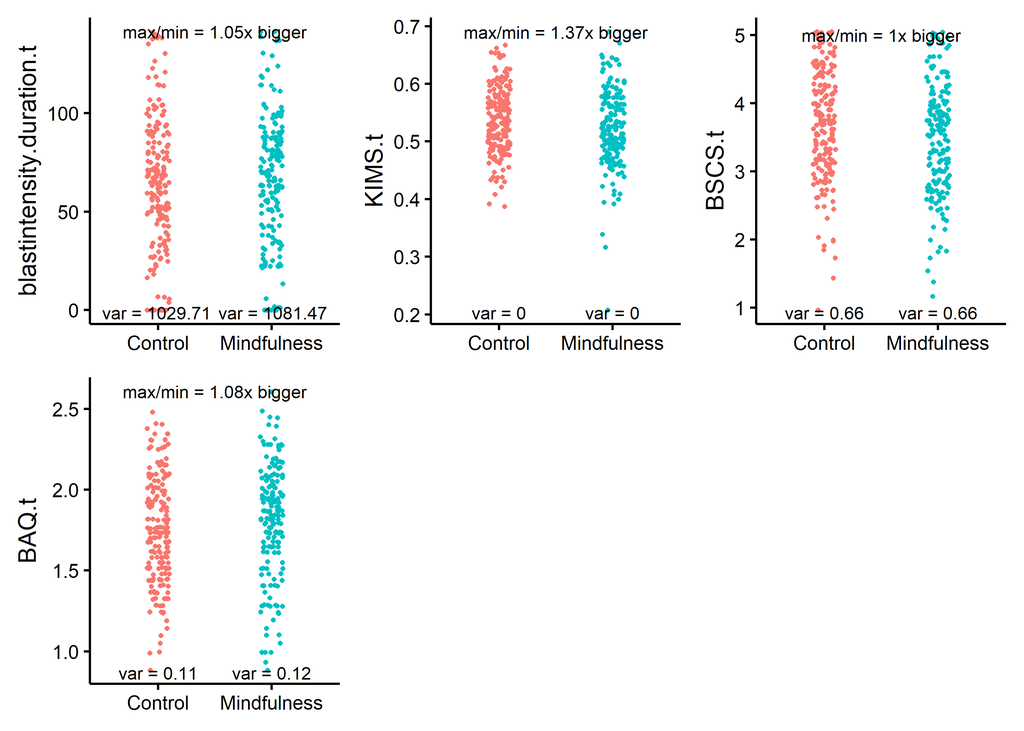

```r
# Plotting variance
plots(lapply(col.list, function(x) {
  nice_varplot(data, x, group = "condition")
  }),
  n_columns = 3)
```

Variance looks good. No group has four times the variance of any other group. We can now resume with checking outliers.

## Outliers

We check outliers visually with the `plot_outliers` function, which draws red lines at +/- 3 median absolute deviations.

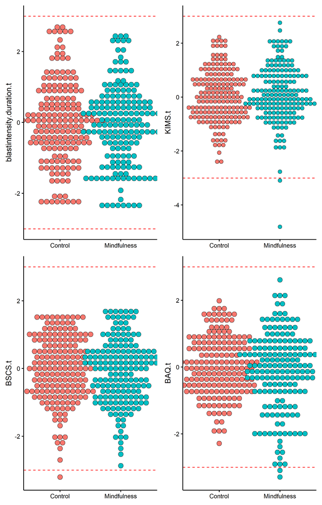

```r
plots(lapply(col.list, function(x) {
  plot_outliers(data, x, group = "condition", ytitle = x, binwidth = 0.15)
  }),
  n_columns = 2)
```

There are some outliers, but nothing unreasonable. Let’s still check with the 3 median absolute deviations (MAD) method.

```r
data %>%
  #as.data.frame %>%
  filter(condition == "Control") %>%
  find_mad(col.list, criteria = 3)
```

```
## 1 outlier(s) based on 3 median absolute deviations for variable(s):
##  blastintensity.duration.t, KIMS.t, BSCS.t, BAQ.t
##
## Outliers per variable:
##
## $BSCS.t
##   Row BSCS.t_mad
## 1  30  -3.203831
```

```r
data %>%
  #as.data.frame %>%
  filter(condition == "Mindfulness") %>%
  find_mad(col.list, criteria = 3)
```

```
## 4 outlier(s) based on 3 median absolute deviations for variable(s):
##  blastintensity.duration.t, KIMS.t, BSCS.t, BAQ.t
##
## Outliers per variable:
##
## $KIMS.t
##   Row KIMS.t_mad
## 1 139  -4.810424
## 2 163  -3.095567
##
## $BAQ.t
##   Row BAQ.t_mad
## 1   2 -3.096044
## 2  11 -3.293408
```

### Multivariate outliers

For multivariate outliers, it is recommended to use the Minimum Covariance Determinant, a robust version of the Mahalanobis distance (MCD, Leys et al., 2019).

Leys, C., Delacre, M., Mora, Y. L., Lakens, D., & Ley, C. (2019). How to classify, detect, and manage univariate and multivariate outliers, with emphasis on pre-registration. *International Review of Social Psychology*, *32*(1).

```r
x <- check_outliers(na.omit(data[col.list]), method = "mcd")
x
```

```
## 3 outliers detected: cases 70, 254, 285.
## - Based on the following method and threshold: mcd (20).
## - For variables: blastintensity.duration.t, KIMS.t, BSCS.t, BAQ.t.
```

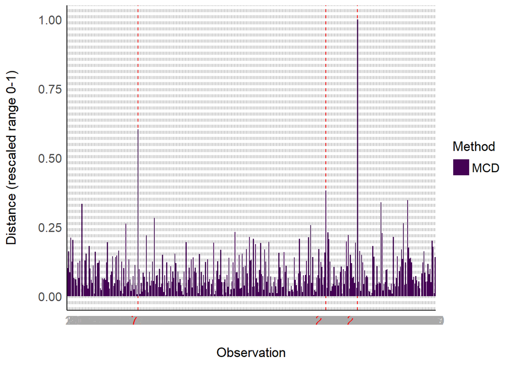

```r
plot(x)
```

There are 3 multivariate outliers according to the MCD method using an artificially high threshold. However, we did not mention in the preregistration that we would exclude multivariate outliers, so we will not at this time.

## Winsorization

Visual assessment and the MAD method confirm we have some outlier values. We could ignore them but because they could have disproportionate influence on the models, one recommendation is to winsorize them by bringing the values at 3 SD. Instead of using the standard deviation around the mean, however, we use the absolute deviation around the median, as it is more robust to extreme observations. For a discussion, see:

Leys, C., Klein, O., Bernard, P., & Licata, L. (2013). Detecting outliers: Do not use standard deviation around the mean, use absolute deviation around the median. *Journal of Experimental Social Psychology, 49*(4), 764–766. https://doi.org/10.1016/j.jesp.2013.03.013

```r
# Winsorize variables of interest with MAD
data <- data %>%
  group_by(condition) %>%
  mutate(across(all_of(col.list),
                winsorize_mad,
                .names = "{.col}.w")) %>%
  ungroup()

col.list <- paste0(col.list, ".w")
```

Outliers are still present but were brought back within reasonable limits, where applicable.

## Standardization

We can now standardize our variables.

```r
data <- data %>%
  mutate(across(all_of(col.list),
                function(x) {
                  as.numeric(scale(x))
                  },
                .names = "{col}.s"))

# Update col.list
col.list <- paste0(col.list, ".s")
```

We are now ready to compare the group condition (Control vs. Mindfulness Priming) across our different variables with the t-tests.

## t-tests

```r
nice_t_test(data,
            response = col.list,
            group = "condition") %>%
  nice_table(highlight = 0.10, width = .80)
```

```
## Using Welch t-test (base R's default; cf. https://doi.org/10.5334/irsp.82).
## For the Student t-test, use `var.equal = TRUE`.
##
```

| Dependent Variable | t | df | p | d | 95% CI |
| --- | --- | --- | --- | --- | --- |
| blastintensity.duration.t.w.s | -0.64 | 358.80 | .520 | -0.07 | [-0.27, 0.14] |
| KIMS.t.w.s | 2.12 | 351.85 | .035* | 0.22 | [0.02, 0.43] |
| BSCS.t.w.s | 2.35 | 359.45 | .019* | 0.25 | [0.04, 0.45] |
| BAQ.t.w.s | -1.65 | 358.38 | .099 | -0.17 | [-0.38, 0.03] |

> **Interpretation:** There is no effect whatsoever on sound blast. However, there seems to be baseline group differences in terms of self-control, trait aggression, and trait mindfulness, despite the block randomization.

## Violin plots

### Intensity * Duration

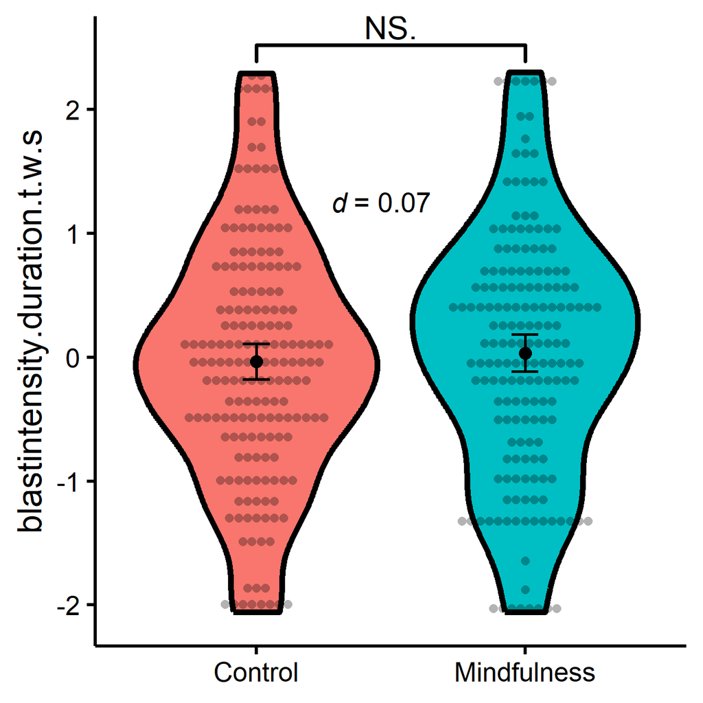

```r
nice_violin(data,
            group = "condition",
            response = "blastintensity.duration.t.w.s",
            comp1 = 1,
            comp2 = 2,
            obs = TRUE,
            has.d = TRUE,
            d.y = 1)
```

## Means, SD

Let’s extract the means and standard deviations for journal reporting.

### Intensity * Duration

```r
data %>%
    group_by(condition) %>%
    summarize(M = mean(blastintensity.duration),
              SD = sd(blastintensity.duration),
              N = n()) %>%
  nice_table()
```

| condition | M | SD | N |
| --- | --- | --- | --- |
| Control | 5,331.04 | 4,567.67 | 184 |
| Mindfulness | 5,676.18 | 4,662.31 | 178 |

# Moderations (confirmatory)

Let’s see if our variables don’t interact together with our experimental condition. But first, let’s test the models assumptions.

## Assumptions

### Intensity * Duration

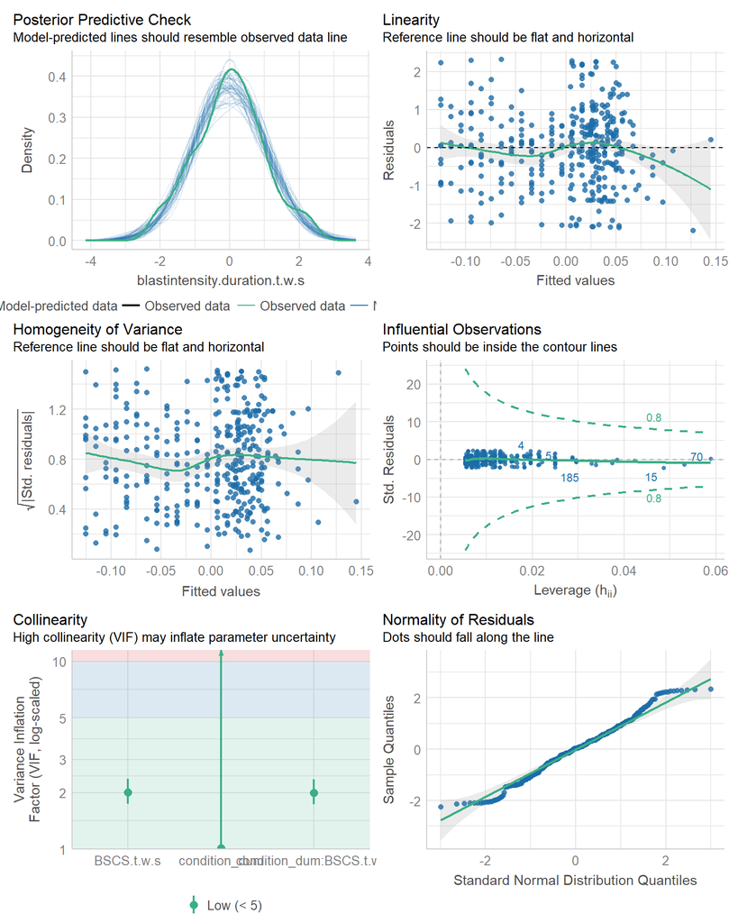

```r
mod1 <- lm(blastintensity.duration.t.w.s ~ condition_dum*BSCS.t.w.s,
           data = data, na.action = "na.exclude")

check_model(mod1)
```

All the models assumptions look pretty good overall actually, even with all these variables. The lines for linearity and homoscedasticity are a bit skewed but nothing too crazy. Let’s now look at the results.

## Moderations

### Intensity * Duration

```r
mod1 %>%
  nice_lm() %>%
  nice_table(highlight = TRUE)
```

| Dependent Variable | Predictor | df | b | t | p | sr2 | 95% CI |
| --- | --- | --- | --- | --- | --- | --- | --- |
| blastintensity.duration.t.w.s | condition_dum | 358 | 0.06 | 0.55 | .580 | .00 | [0.00, 0.01] |
|  | BSCS.t.w.s | 358 | -0.06 | -0.77 | .442 | .00 | [0.00, 0.01] |
|  | condition_dum × BSCS.t.w.s | 358 | 0.04 | 0.39 | .698 | .00 | [0.00, 0.00] |

> **Interpretation:** The condition by trait self-control (brief self-control scale, BSCS) interaction does not come up.

## Interaction plots

Let’s plot the main interaction(s).

### Intensity * Duration

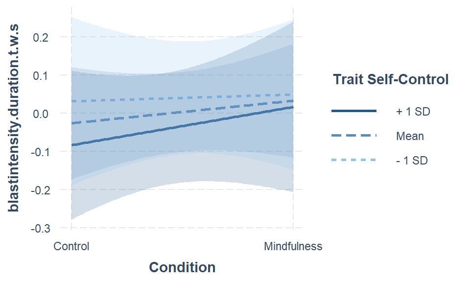

```r
interact_plot(mod1, pred = "condition_dum", modx = "BSCS.t.w.s",
              modxvals = NULL, interval = TRUE, x.label = "Condition",
              pred.labels = c("Control", "Mindfulness"),
              legend.main = "Trait Self-Control")
```

> **Interpretation:** There is no interaction.

# Moderations (exploratory)

Let’s see if our variables don’t interact together with our experimental condition. But first, let’s test the models assumptions.

## Assumptions

### Intensity * Duration

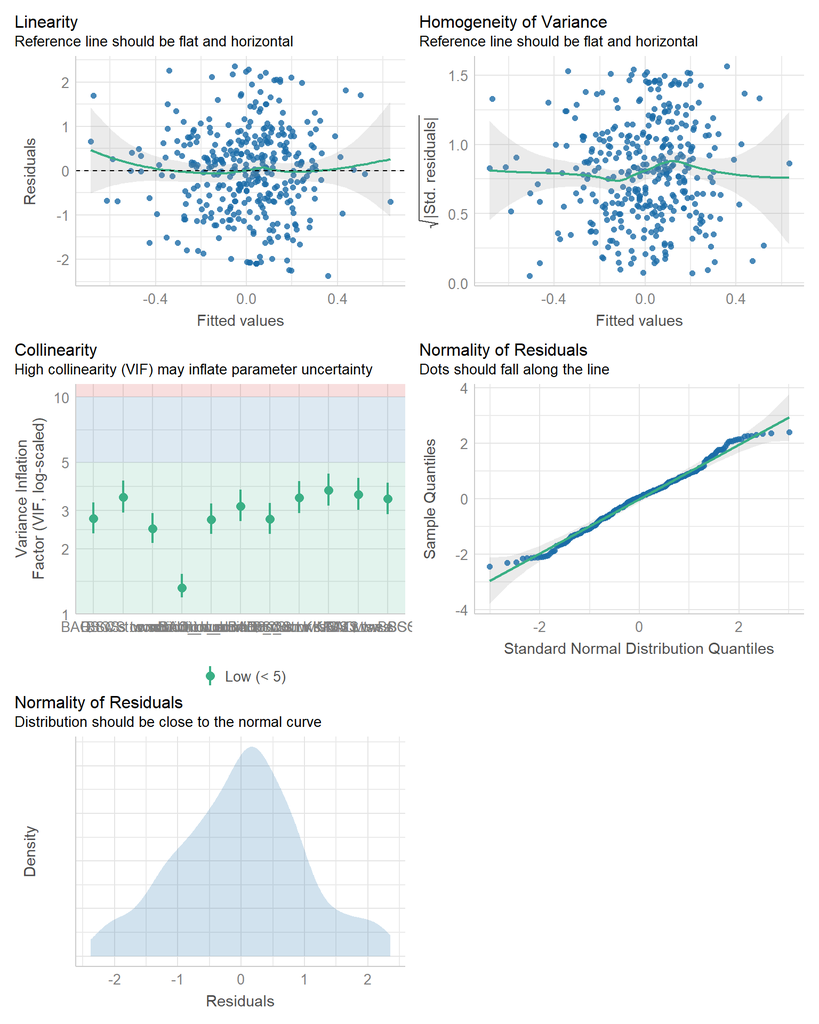

```r
mod1 <- lm(blastintensity.duration.t.w.s ~ condition_dum * KIMS.t.w.s*BSCS.t.w.s +
             condition_dum*BAQ.t.w.s*BSCS.t.w.s,
           data = data, na.action = "na.exclude")
check_model(mod1)
```

All the models assumptions look pretty good overall actually, even with all these variables. The lines for linearity and homoscedasticity are a bit skewed but nothing too crazy. Let’s now look at the results.

## Moderations

### Intensity * Duration

```r
mod1 %>%
  nice_lm() %>%
  nice_table(highlight = TRUE)
```

[output not shown]

> **Interpretation:** The condition by trait self-control (brief self-control scale, BSCS) interaction does not come up.

## Interaction plots

Let’s plot the main significant interaction(s).

### Intensity * Duration

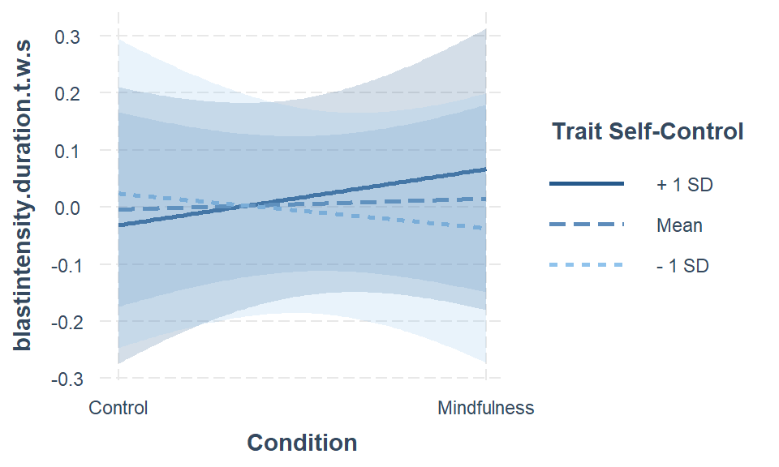

```r
interact_plot(mod1, pred = "condition_dum", modx = "BSCS.t.w.s",
              modxvals = NULL, interval = TRUE, x.label = "Condition",
              pred.labels = c("Control", "Mindfulness"),
              legend.main = "Trait Self-Control")
```

> **Interpretation:** There is no interaction.

# Conclusions

Based on the results, it seems that the predicted interaction between self-control and the priming mindfulness manipulation does not come up.

# Full Code

The full script of executive code contained in this document is reproduced here.

```r
fast <- FALSE  # Make this true to skip the chunks
klippy::klippy(position = c('top', 'right'))

library(rempsyc)
library(dplyr)
library(interactions)
library(performance)
library(see)
library(report)
library(datawizard)
library(bestNormalize)
library(psych)
library(visdat)
library(missForest)
library(doParallel)
library(naniar)

summary(report(sessionInfo()))

# Read data
data <- read.table("https://osf.io/ecqng/?action=download", sep = "\t", header = TRUE)

# Dummy-code group variable
data <- data %>%
  mutate(condition_dum = ifelse(condition == "Mindfulness", 1, 0),
         condition = as.factor(condition))

cat(report_participants(data, threshold = 1))

# Allocation ratio
report(data$condition)

# Make list of DVs
col.list <- c("blastintensity.duration", "KIMS", "BSCS", "BAQ")

report::cite_packages(sessionInfo())

data %>%
    summarize(success.80 = sum(manipsuccessleft < .80,
                               na.rm = TRUE),
              is.na = sum(is.na(manipsuccessleft)))

data <- data %>%
    filter(manipsuccessleft >= .80)

cat(report_participants(data, threshold = 1))

data <- data %>%
    mutate(att_check = rowSums(
      select(., att_check1, att_check2, att_check3)))

data %>%
  count(att_check)

data <- data %>%
  filter(att_check >= 2)

cat(report_participants(data, threshold = 1))

report(data$condition)

# Check for nice_na
nice_na(data, scales = c("BSCS", "BAQ", "KIMS"))

# Smaller subset of data for easier inspection
data %>%
  select(country.ip:att_check2_raw,
         condition:condition_dum) %>%
  vis_miss

# Let's use Little's MCAR test to confirm
# We have to proceed by "scale" because the function can only
# support 30 variables max at a time
data %>%
  select(KIMS_1:KIMS_20) %>%
  mcar_test

data %>%
  select(KIMS_21:KIMS_39) %>%
  mcar_test

# Need character variables as factors
# "Error: Can not handle categorical predictors with more than 53 categories."
# So we have to temporarily remove some variables also...
new.data <- data %>%
  select(-c(att_check1, att_check2, att_check3)) %>%
  mutate(across(where(is.character), as.factor))

# Parallel processing
registerDoParallel(cores = 4)

# Variables
set.seed(100)
data.imp <- missForest(new.data, verbose = TRUE, parallelize = "variables")
# Total time is 2 sec (4*0.5) - 4 cores

# Extract imputed dataset
new.data <- data.imp$ximp

# Add back the NAs in country, attention checks, etc.
data <- new.data %>%
  mutate(country.ip = data$country.ip,
         gender = data$gender,
         att_check1 = data$att_check1,
         att_check2 = data$att_check2,
         att_check3 = data$att_check3)

# Reverse code items 2, 4, 6, 7
data <- data %>%
  mutate(across(starts_with("BSCS"), .names = "{col}r"))

data <- data %>%
  mutate(across(c(BSCS_2, BSCS_4, BSCS_6, BSCS_7), ~nice_reverse(.x, 5), .names = "{col}r"))

# Get mean BSCS
data <- data %>%
  mutate(BSCS = rowMeans(select(., BSCS_1r:BSCS_7r)))

# Reverse code item 7
data <- data %>%
  mutate(across(starts_with("BAQ"), .names = "{col}r"))

data <- data %>%
  mutate(across(BAQ_7, ~nice_reverse(.x, 7), .names = "{col}r"))

# Get sum of BAQ
data <- data %>%
  mutate(BAQ = rowMeans(select(., BAQ_1r:BAQ_12r)))

# Reverse code items 3-4, 8, 11-12, 14, 16, 18, 20, 22, 23-24, 27-28, 31-32, 35-36
data <- data %>%
  mutate(across(starts_with("KIMS"), .names = "{col}r"))

data <- data %>%
  mutate(across(all_of(paste0("KIMS_", c(3:4, 8, 11:12, 14, 16, 18, 20,
                                         22:24, 27:28, 31:32, 35:36))),
                ~nice_reverse(.x, 5), .names = "{col}r"))

# Get sum of KIMS
data <- data %>%
  mutate(KIMS = rowMeans(select(., KIMS_1r:KIMS_39r)))

# Create new variable blastintensity.duration
data <- data %>%
  mutate(blastintensity.duration = blastintensity * blastduration)

data %>%
  select(BSCS_1r:BSCS_7r) %>%
  omega(nfactors = 1)

data %>%
  select(BAQ_1r:BAQ_12r) %>%
  omega(nfactors = 1)

data %>%
  select(KIMS_1r:KIMS_39r) %>%
  omega(nfactors = 1)

#labels.part2$KIMS_8

lapply(col.list, function(x)
  nice_normality(data,
                 variable = x,
                 title = x,
                 group = "condition",
                 shapiro = TRUE,
                 histogram = TRUE))

predict_bestNormalize <- function(var) {
  x <- bestNormalize(var, standardize = FALSE, allow_orderNorm = FALSE)
  print(cur_column())
  print(x$chosen_transform)
  cat("\n")
  predict(x)
}

set.seed(100)
data <- data %>%
  mutate(across(all_of(col.list),
                predict_bestNormalize,
                .names = "{.col}.t"))
col.list <- paste0(col.list, ".t")

# Group normality
lapply(col.list, function(x)
  nice_normality(data,
                 x,
                 "condition",
                 shapiro = TRUE,
                 title = x,
                 histogram = TRUE))

# Plotting variance
plots(lapply(col.list, function(x) {
  nice_varplot(data, x, group = "condition")
  }),
  n_columns = 3)

plots(lapply(col.list, function(x) {
  plot_outliers(data, x, group = "condition", ytitle = x, binwidth = 0.15)
  }),
  n_columns = 2)

data %>%
  #as.data.frame %>%
  filter(condition == "Control") %>%
  find_mad(col.list, criteria = 3)

data %>%
  #as.data.frame %>%
  filter(condition == "Mindfulness") %>%
  find_mad(col.list, criteria = 3)

x <- check_outliers(na.omit(data[col.list]), method = "mcd")
x

plot(x)

# Winsorize variables of interest with MAD
data <- data %>%
  group_by(condition) %>%
  mutate(across(all_of(col.list),
                winsorize_mad,
                .names = "{.col}.w")) %>%
  ungroup()

col.list <- paste0(col.list, ".w")

data <- data %>%
  mutate(across(all_of(col.list),
                function(x) {
                  as.numeric(scale(x))
                  },
                .names = "{col}.s"))

# Update col.list
col.list <- paste0(col.list, ".s")

nice_t_test(data,
            response = col.list,
            group = "condition") %>%
  nice_table(highlight = 0.10, width = .80)

nice_violin(data,
            group = "condition",
            response = "blastintensity.duration.t.w.s",
            comp1 = 1,
            comp2 = 2,
            obs = TRUE,
            has.d = TRUE,
            d.y = 1)

data %>%
    group_by(condition) %>%
    summarize(M = mean(blastintensity.duration),
              SD = sd(blastintensity.duration),
              N = n()) %>%
  nice_table()

mod1 <- lm(blastintensity.duration.t.w.s ~ condition_dum*BSCS.t.w.s,
           data = data, na.action = "na.exclude")

check_model(mod1)

mod1 %>%
  nice_lm() %>%
  nice_table(highlight = TRUE)

mod1 %>%
  nice_lm() %>%
  mutate(`Dependent Variable` = "Aggression",
         Predictor = text_remove(.data$Predictor, "_dum") %>%
           text_remove(".t.w.s")) %>%
  nice_table(
    highlight = TRUE,
    title = c("Table 3", "Testing the Condition × Self-Control Interaction"),
    note = "Aggression refers to the product of blast intensity and blast duration in the Taylor Paradigm. BSCS: trait self-control. There are no significant interactions.") %>%
  flextable::save_as_docx(path = "modtable1.docx")

interact_plot(mod1, pred = "condition_dum", modx = "BSCS.t.w.s",
              modxvals = NULL, interval = TRUE, x.label = "Condition",
              pred.labels = c("Control", "Mindfulness"),
              legend.main = "Trait Self-Control")

mod1 <- lm(blastintensity.duration.t.w.s ~ condition_dum * KIMS.t.w.s*BSCS.t.w.s +
             condition_dum*BAQ.t.w.s*BSCS.t.w.s,
           data = data, na.action = "na.exclude")
check_model(mod1)

mod1 %>%
  nice_lm() %>%
  nice_table(highlight = TRUE)

mod1 %>%
  nice_lm() %>%
  mutate(`Dependent Variable` = "Aggression",
         Predictor = text_remove(.data$Predictor, "_dum") %>%
           text_remove(".t.w.s")) %>%
  nice_table(
    highlight = TRUE,
    title = c("Table 4", "Exploring Other Personality Moderators of Priming Mindfulness"),
    note = "Aggression refers to the product of blast intensity and blast duration in the Taylor Paradigm. KIMS: trait mindfulness; BSCS: trait self-control; BAQ: trait aggression. There are no significant interactions.") %>%
  flextable::save_as_docx(path = "modtable2.docx")

interact_plot(mod1, pred = "condition_dum", modx = "BSCS.t.w.s",
              modxvals = NULL, interval = TRUE, x.label = "Condition",
              pred.labels = c("Control", "Mindfulness"),
              legend.main = "Trait Self-Control")
```

# Package References

```r
report::cite_packages(sessionInfo())
```

- Analytics R, Weston S (2022). *iterators: Provides Iterator Construct*. R package version 1.0.14, https://CRAN.R-project.org/package=iterators.
- Corporation M, Weston S (2022). *doParallel: Foreach Parallel Adaptor for the ‘parallel’ Package*. R package version 1.0.17, https://CRAN.R-project.org/package=doParallel.
- Long JA (2019). *interactions: Comprehensive, User-Friendly Toolkit for Probing Interactions*. R package version 1.1.0, https://cran.r-project.org/package=interactions.
- Lüdecke D, Ben-Shachar M, Patil I, Waggoner P, Makowski D (2021). “performance: An R Package for Assessment, Comparison and Testing of Statistical Models.” *Journal of Open Source Software*, *6*(60), 3139. doi:10.21105/joss.03139 https://doi.org/10.21105/joss.03139.
- Lüdecke D, Patil I, Ben-Shachar M, Wiernik B, Waggoner P, Makowski D (2021). “see: An R Package for Visualizing Statistical Models.” *Journal of Open Source Software*, *6*(64), 3393. doi:10.21105/joss.03393 https://doi.org/10.21105/joss.03393.
- Makowski D, Lüdecke D, Patil I, Thériault R, Ben-Shachar M, Wiernik B (2023). “Automated Results Reporting as a Practical Tool to Improve Reproducibility and Methodological Best Practices Adoption.” *CRAN*. https://easystats.github.io/report/.
- Microsoft, Weston S (2022). *foreach: Provides Foreach Looping Construct*. R package version 1.5.2, https://CRAN.R-project.org/package=foreach.
- Patil I, Makowski D, Ben-Shachar M, Wiernik B, Bacher E, Lüdecke D (2022). “datawizard: An R Package for Easy Data Preparation and Statistical Transformations.” *Journal of Open Source Software*, *7*(78), 4684. doi:10.21105/joss.04684 https://doi.org/10.21105/joss.04684.
- Peterson RA (2021). “Finding Optimal Normalizing Transformations via bestNormalize.” *The R Journal*, *13*(1), 310-329. doi:10.32614/RJ-2021-041 https://doi.org/10.32614/RJ-2021-041. Peterson RA, Cavanaugh JE (2020). “Ordered quantile normalization: a semiparametric transformation built for the cross-validation era.” *Journal of Applied Statistics*, *47*(13-15), 2312-2327. doi:10.1080/02664763.2019.1630372 https://doi.org/10.1080/02664763.2019.1630372.
- R Core Team (2022). *R: A Language and Environment for Statistical Computing*. R Foundation for Statistical Computing, Vienna, Austria. https://www.R-project.org/.
- Stekhoven DJ (2022). *missForest: Nonparametric Missing Value Imputation using Random Forest*. R package version 1.5. Stekhoven DJ, Buehlmann P (2012). “MissForest - non-parametric missing value imputation for mixed-type data.” *Bioinformatics*, *28*(1), 112-118.
- Thériault R (2022). “rempsyc: Convenience Functions for Psychology.” (R package version 0.1.1.6) [Computer software]., https://rempsyc.remi-theriault.com.
- Tierney N (2017). “visdat: Visualising Whole Data Frames.” *JOSS*, *2*(16), 355. doi:10.21105/joss.00355 https://doi.org/10.21105/joss.00355, http://dx.doi.org/10.21105/joss.00355.
- Tierney N, Cook D (2023). “Expanding Tidy Data Principles to Facilitate Missing Data Exploration, Visualization and Assessment of Imputations.” *Journal of Statistical Software*, *105*(7), 1-31. doi:10.18637/jss.v105.i07 https://doi.org/10.18637/jss.v105.i07.
- Wickham H, François R, Henry L, Müller K, Vaughan D (2023). *dplyr: A Grammar of Data Manipulation*. R package version 1.1.1, https://CRAN.R-project.org/package=dplyr.
- William Revelle (2023). *psych: Procedures for Psychological, Psychometric, and Personality Research*. Northwestern University, Evanston, Illinois. R package version 2.3.3, https://CRAN.R-project.org/package=psych.